# GEL - Summary statistics from annotated dataframes

Sam Tallman

16 December, 2025

# 1 Packages

```r
library(tidyverse)
library(data.table)
library(MASS)
library(magrittr)
library(viridis)
library(broom)
library(Rcpp)
library(cowplot)
library(ggpubr)
library(zoo)
library(reticulate)
library(polars)
library(tidypolars)
library(glue)
library(scales)
library(purrr)
library(rtracklayer)
library(GenomicRanges)

## conda environment.
use_virtualenv("/opt/python_env", required = TRUE)
```

# 2 Parameters

```r
## Python functions for reticulate
source_python("functions/gel-funcs.py")

## Source R functions
source("functions/gel-funcs.R")
source("functions/gel-plotting_funcs.R")
```

File paths from config…

```r
config <- yaml::read_yaml("config/config.yaml")

# Fill templates
paths <- lapply(config$paths, function(path) {
  if (grepl("\\{chrom\\}|\\{chrom_no_prefix\\}", path)) {
    return(NULL)   # skip chrom-templated paths
  }
  glue(path,
       data_dir       = config$paths$data_dir,
       singletons_dir = config$paths$singletons_dir
  )
})

paths <- Filter(Negate(is.null), paths)
```

Total individuals - Total individuals, total unrelated individuals < 3rd degree

```r
pops_df <- read_tsv(paths$pops_path)
## Unrelated pops
unrel_pops_df <- pops_df |>
unrelated_filter(
  sample_col = "sgkit_sample_id",
  aggV2_kinship_matrix = paths$aggV2_kinship_matrix,
  kinship_coefficient = 0.0442
)
```

```
## Number of relatives removed: 4849
```

```r
## List of trees (with singletons included)
ts_tsv = params$ts_tsv
# ts_tsv = "/pgen_int_work/BRS/dd/sam/projects/gel-dating-paper/trees_singletons_july25.tsv"
trees_list <- read_tsv(ts_tsv)
ts_dir <- paths$ts_dir
```

# 3 Data

We read in the relevant data from chromosomes

```r
# Extract relevant columns from the ts_df for chromosome 17
selected_columns <- c(
    "chromosome",
    "position",
    "ancestral_state",
    "derived_state",
    "ts_name",
    "AC_ts",
    "AF_ts",
    "consequence",
    "cpg_transition",
    "shape_time",
    "scale_time",
    "upper_conf_time",
    "lower_conf_time",
    "sd_time",
    "cv_time",
    "in_gnomad",
    "mean_time",
    "mutation_root_parent",
    "pop",
    "singleton_sample_id"
  )
```

Lazy loading for filtering etc. Combine the ts_df (parquet) from gel-ts_df.Rmd (all chromosomes)

```r
ts_lf_merge <- scan_parquet_polars(file.path(paths$output_dir, "all-chr*-df.parquet")) |>
  dplyr::select(all_of(selected_columns))  |>
  compute()
```

Add edge spans

```r
edge_span_list <- list()
ts_names_vec <- unique(ts_lf_merge |> pull(ts_name))

for (index in 1:length(ts_names_vec)) {
  tree <- trees_list |>
    filter(grepl(ts_names_vec[index], ts_prefix))
  edge_file <- paste0(
    paths$output_dir,
    "checkpoints/all-",
    ts_names_vec[index],
    "-edge_spans.tsv.gz"
  )
  if (file.exists(edge_file )) {
    print(tree$chromosome)
    edge_span_list[[index]] <- read_tsv(edge_file) |>
      mutate(chromosome = tree$chromosome)
  } else {
    ts_name_now <- ts_names_vec[index]
    var_df <- ts_lf_merge |>
      filter(ts_name == ts_name_now) |>
      as_tibble()
    edge_df  <- edge_span_mutations(
      ts_path = paste0(ts_dir, tree$ts_prefix, ".trees.tsz"),
      positions = var_df$position
    ) |>
      mutate(chromosome = tree$chromosome)
    edge_df |>
      fwrite(
        file.path(edge_file), sep = "\t"
      )
     edge_span_list[[index]] <- edge_df
  }
}
```

```
## [1] "chr16"
```

```
## [1] "chr16"
```

```
## [1] "chr17"
```

```
## [1] "chr17"
```

```
## [1] "chr17"
```

```
## [1] "chr17"
```

```
## [1] "chr17"
```

```
## [1] "chr18"
```

```
## [1] "chr19"
```

```
## [1] "chr20"
```

```
## [1] "chr20"
```

```
## [1] "chr21"
```

```
## [1] "chr21"
```

```
## [1] "chr22"
```

```
## [1] "chr22"
```

Join with the lazy frame

```r
edges_df <- do.call(rbind, edge_span_list) |>
mutate(
  edge_span_kb = (edge_right - edge_left) / 1000
)
edges_lf <- as_polars_lf(edges_df) |>
  compute()

ts_lf_merge %<>%
left_join(
  edges_lf, by = c("chromosome", "position")
)
```

# 4 Simple summary statistics

How many total individuals?

```r
n_inds <- nrow(pops_df)

cat(
  "There are", n_inds, "total individuals in the tree sequences.\n"
)
```

```
## There are 47535 total individuals in the tree sequences.
```

How many total unrelated individuals?

```r
n_unrel_inds <- nrow(unrel_pops_df)

cat(
  "There are", n_unrel_inds, "in the tree sequence without any < 3rd degree relatives.\n"
)
```

```
## There are 42686 in the tree sequence without any < 3rd degree relatives.
```

How many different contigs used for inference / dating?

```r
n_total_contigs <- ts_lf_merge |>
  pull(ts_name) |>
  unique() |>
  length()

cat(
  "There are", n_total_contigs, "distinct chromosomal segments used for dating / inference.\n"
)
```

```
## There are 15 distinct chromosomal segments used for dating / inference.
```

Number of total mutations across all chromosomes

```r
# variable sites
n_total_sites <- nrow(ts_lf_merge)
cat(
  "There are", n_total_sites, "variants across all tree sequences.\n"
)
```

```
## There are 23224299 variants across all tree sequences.
```

How many have dates?

```r
# variable sites
n_sites_w_dates <- nrow(ts_lf_merge |> drop_na(mean_time))

cat(
  "There are", n_total_sites - n_sites_w_dates , "variants without associated dates\n"
)
```

```
## There are 23 variants without associated dates
```

How many singletons were appended to terminal branches?

```r
n_singletons_total <- nrow(ts_lf_merge |> filter(AC_ts == 1))

cat(
  "There are", n_singletons_total, "singleton variants (DAC = 1) across all tree sequences\n"
)
```

```
## There are 11778316 singleton variants (DAC = 1) across all tree sequences
```

How many singletons among unrelated individuals (used for singleton analyses)

```r
n_singletons_unrel <- nrow(ts_lf_merge |> filter(AC_ts == 1 & singleton_sample_id %in% unrel_pops_df$sgkit_sample_id))

cat(
  "There are", n_singletons_unrel, "singleton variants (DAC = 1) among the unrelated participants in the tree sequences\n"
)
```

```
## There are 10981508 singleton variants (DAC = 1) among the unrelated participants in the tree sequences
```

Edges + ancestral nodes

```r
## Number of ancestors / edges
ts_names_vec <- unique(ts_lf_merge |> pull(ts_name))
n_ancestors <- 0
n_edges <- 0
for (index in 1:length(ts_names_vec)) {
  tree <- trees_list |>
    filter(grepl(ts_names_vec[index], ts_prefix))
  n_ancestors_tree <- no_ancestors(
      ts_path = paste0(ts_dir, tree$ts_prefix, ".trees.tsz")
  )
  n_ancestors <- n_ancestors + n_ancestors_tree
  n_edges_tree <- no_edges(
      ts_path = paste0(ts_dir, tree$ts_prefix, ".trees.tsz")
  )
  n_edges <- n_edges + n_edges_tree
}
```

How many edges across all tree sequences?

```r
cat(
  "There are", n_edges , "edges across all tree sequences\n"
)
```

```
## There are 141284185 edges across all tree sequences
```

How many ancestral nodes across all tree sequences?

```r
cat(
  "There are", n_ancestors , "ancestral nodes across all tree sequences\n"
)
```

```
## There are 16806547 ancestral nodes across all tree sequences
```

How many mutations whose parents are root nodes? - These are excluded from all downstream analyses …

```r
n_mutation_root <- ts_lf_merge |>
  filter(
    mutation_root_parent
  ) |>
  nrow()

cat(
  "There are", n_mutation_root , "mutations whose parents are unconstrained root nodes in the tree sequences\n"
)
```

```
## There are 145109 mutations whose parents are unconstrained root nodes in the tree sequences
```

How many sites are unobserved in the gnomADv4.1 reference database?

```r
# variable sites
n_in_gnomad_sites <- nrow(ts_lf_merge |> filter(in_gnomad))

cat(
  "There are", n_total_sites - n_in_gnomad_sites , "mutations in the tree sequences unobserved in gnomADv4.1\n"
)
```

```
## There are 9617785 mutations in the tree sequences unobserved in gnomADv4.1
```

Tabulate simple statistics

```r
# Fallbacks to avoid errors if some optional objects aren't present
val_or_na <- function(x) if (exists(x, inherits = TRUE)) get(x) else NA_integer_

n_edges_val     <- val_or_na("n_edges")
n_ancestors_val <- val_or_na("n_ancestors")

# Derived from your existing counts
n_sites_wo_dates <- n_total_sites - n_sites_w_dates
n_not_in_gnomad  <- n_total_sites - n_in_gnomad_sites

summary_tbl <- tibble(
  Metric = c(
    "Individuals (total)",
    "Individuals (unrelated; no <3rd-degree)",
    "Chromosomal segments used",
    "Variants (total)",
    "Variants with dates",
    "Variants without dates",
    "Singleton variants (DAC = 1)",
    "Singletons among unrelated participants",
    "Edges across all tree sequences",
    "Ancestral nodes across all tree sequences",
    "Mutations with unconstrained-root parents",
    "Mutations unobserved in gnomAD v4.1"
  ),
  Value = c(
    n_inds,
    n_unrel_inds,
    n_total_contigs,
    n_total_sites,
    n_sites_w_dates,
    n_sites_wo_dates,
    n_singletons_total,
    n_singletons_unrel,
    n_edges,
    n_ancestors,
    n_mutation_root,
    n_not_in_gnomad
  ),
  `% of total variants` = c(
    NA,
    NA,
    NA,
    100,
    100 * n_sites_w_dates    / n_total_sites,
    100 * n_sites_wo_dates   / n_total_sites,
    100 * n_singletons_total / n_total_sites,
    100 * n_singletons_unrel / n_total_sites,
    NA,
    NA,
    100 * n_mutation_root    / n_total_sites,
    100 * n_not_in_gnomad    / n_total_sites
  )
) |>
  mutate(
    Value = comma(Value),
    `% of total variants` = ifelse(
      is.na(`% of total variants`), "",
      percent(`% of total variants` / 100, accuracy = 0.1)
    )
  )

knitr::kable(summary_tbl, align = c("l","r","r"), caption = "Dataset summary")
```

Dataset summary

| Metric | Value | % of total variants |
| --- | --- | --- |
| Individuals (total) | 47,535 |  |
| Individuals (unrelated; no <3rd-degree) | 42,686 |  |
| Chromosomal segments used | 15 |  |
| Variants (total) | 23,224,299 | 100.0% |
| Variants with dates | 23,224,276 | 100.0% |
| Variants without dates | 23 | 0.0% |
| Singleton variants (DAC = 1) | 11,778,316 | 50.7% |
| Singletons among unrelated participants | 10,981,508 | 47.3% |
| Edges across all tree sequences | 141,284,185 |  |
| Ancestral nodes across all tree sequences | 16,806,547 |  |
| Mutations with unconstrained-root parents | 145,109 | 0.6% |
| Mutations unobserved in gnomAD v4.1 | 9,617,785 | 41.4% |

# 5 Allele ages stats and tables

Mean allele age

```r
mean_age_all <- mean(ts_lf_merge |> filter(mutation_root_parent == FALSE) |> pull(mean_time), na.rm = TRUE)

cat(
  "The mean mutation age across all sites is", mean_age_all, " generations\n"
)
```

```
## The mean mutation age across all sites is 969.9848  generations
```

Geometric mean allele age

```r
geo_mean_age_all <- exp(mean(log(ts_lf_merge |> filter(mutation_root_parent == FALSE) |> pull(mean_time)), na.rm = TRUE))

cat(
  "The geometric mean mutation age across all sites is", geo_mean_age_all, " generations\n"
)
```

```
## The geometric mean mutation age across all sites is 96.812  generations
```

Simple number of mutations by allele age epoch

```r
# Add epochs
ts_lf_merge %<>%
  drop_na(mean_time) %>%
  mutate(
    epoch = case_when(
      mean_time <= 10                  ~ "≤10",
      mean_time > 10   & mean_time <= 100    ~ "11-100",
      mean_time > 100  & mean_time <= 1000  ~ "101-1,000",
      mean_time > 1000 & mean_time <= 10000 ~ "1,001-10,000",
      mean_time > 10000                      ~ ">10,000"
    )
  )

# Youngest to oldest
order_epoch_bins <-
  c(
    "≤10",
    "11-100",
    "101-1,000",
    "1,001-10,000",
    ">10,000"
  )
```

How many mutations per epoch?

```r
epoch_counts <- ts_lf_merge |>
  filter(mutation_root_parent == FALSE) |>
  group_by(epoch) |>
  summarise(
    n_mutations = n()
  ) |>
  as_tibble() |>
  mutate(
    epoch = factor(epoch, levels = order_epoch_bins)
  ) |>
  arrange(epoch) |>
  ungroup() |>
  mutate(
    percentage_of_total = round(100 * (n_mutations / sum(n_mutations)), 1)
  )

knitr::kable(epoch_counts, bookends = FALSE)
```

| epoch | n_mutations | percentage_of_total |
| --- | --- | --- |
| ≤10 | 334555 | 1.4 |
| 11-100 | 13708957 | 59.4 |
| 101-1,000 | 7504839 | 32.5 |
| 1,001-10,000 | 990521 | 4.3 |
| >10,000 | 540318 | 2.3 |

As bar plot

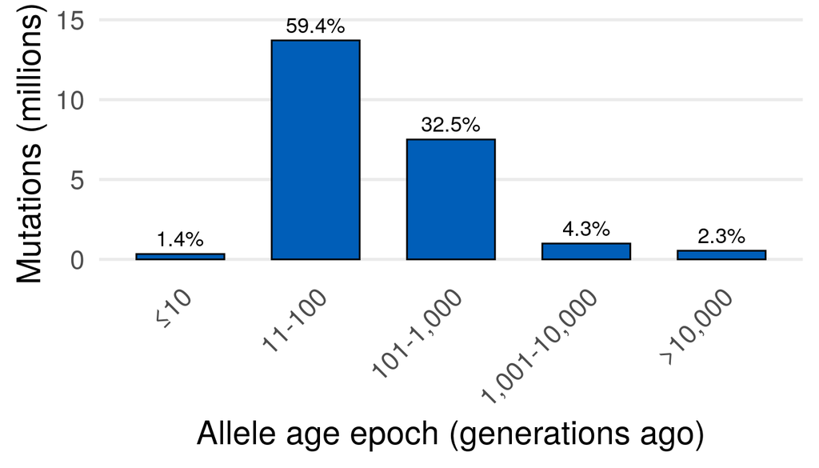

```r
epoch_ages_bar <- epoch_counts |>
  ggplot(aes(
    x = epoch, y = n_mutations / 1000000
  )) +
  geom_bar(stat = "identity", fill = "#005eb8", colour = "black", width = 0.65) +
  theme_minimal(base_size = 20) +
  theme(
    panel.grid.minor = element_blank(),
    panel.grid.major.x = element_blank(),
    legend.position = "NONE",
    axis.text.x = element_text(angle = 45, hjust = 1, vjust = 1)
  ) +
  geom_text(
    aes(label = paste0(round(percentage_of_total, 2), "%"), vjust = -0.5, size = 5)
  ) +
  labs(
    x = "Allele age epoch (generations ago)",
    y = "Mutations (millions)"
  ) +
  scale_y_continuous(limits = c(0, 14.5))
epoch_ages_bar
```

```r
ggsave(paste0(paths$plots_dir, "epoch_ages_bar.pdf"), epoch_ages_bar, width = 7, height = 4)
```

Cumulative % mutations at given age - ECDF is heavy, use 0.01 percentile bins / 0.1 deciles

```r
# (deciles = 0.1, percentiles = 0.01)
probs <- seq(0.01, 0.99, by = 0.01)
x <- ts_lf_merge |>
  filter(mutation_root_parent == FALSE) |>
  dplyr::pull(mean_time)
x <- x[is.finite(x) & x > 0]
qs  <- unname(quantile(x, probs, na.rm = TRUE, names = FALSE))
qdf <- tibble(p = probs, x = qs)
```

Plot

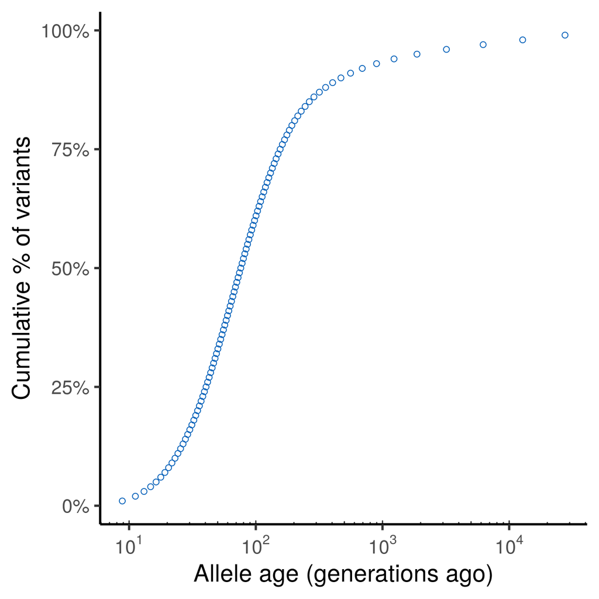

```r
cum_prop_ages <- ggplot(qdf, aes(x = x, y = 100*p)) +
  geom_point(size = 2, shape = 21, colour = "#005eb8") +
  scale_x_log10(
    breaks = trans_breaks("log10", function(z) 10^z),
    labels = trans_format("log10", math_format(10^.x))
  ) +
  scale_y_continuous(labels = label_percent(scale = 1)) +
  labs(x = "Allele age (generations ago)",
       y = "Cumulative % of variants") +
  theme_classic(base_size = 20) +
  annotation_logticks(
        linewidth = 0.5,
        colour = "grey20",
        short = unit(0.05, "cm"),
        mid = unit(0.075, "cm"),
        long = unit(0.1, "cm"),
        sides = "b"
      )
cum_prop_ages
```

```r
ggsave(paste0(paths$plots_dir, "cumul_prop_ages.pdf"), cum_prop_ages, width = 7, height = 7)
```

Majority of variants occurred in last ~80 generations - With 30 years per gen, last ~2,400 years.

#### 5.0.0.1 Summarise allele ages by frequency

Full derived AFS

```r
derived_afs <- ts_lf_merge |>
  group_by(
    AF_ts
  ) |>
  summarise(
    n = n()
  ) |>
  as_tibble() |>
  ungroup() |>
  mutate(
    prop = n / sum(n)
  )
```

Plot

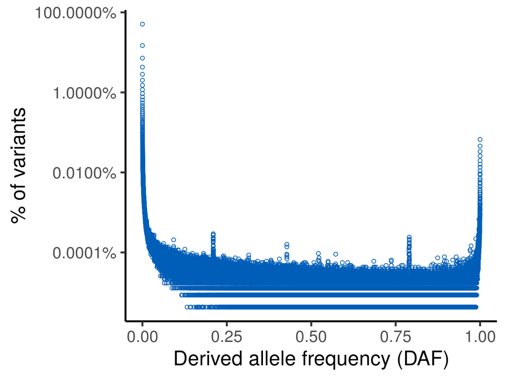

```r
derived_afs_plot <- derived_afs |>
  ggplot(aes(x = AF_ts, y = prop)) +
  geom_point(shape = 21, colour = "#005eb8") +
  scale_y_log10() +
  theme_classic(base_size = 20) +
  scale_y_log10(
    breaks = trans_breaks("log10", function(x) 10^x),
    labels = label_percent(accuracy = 0.0001)
  ) +
  labs(
    y = "% of variants",
    x = "Derived allele frequency (DAF)"
  )
derived_afs_plot
```

```r
ggsave(paste0(paths$plots_dir, "gel_derived_afs.pdf"), derived_afs_plot, width = 7, height = 5.25)
```

Age vs frequency overall plot - Equivalent to simulation of freq vs age

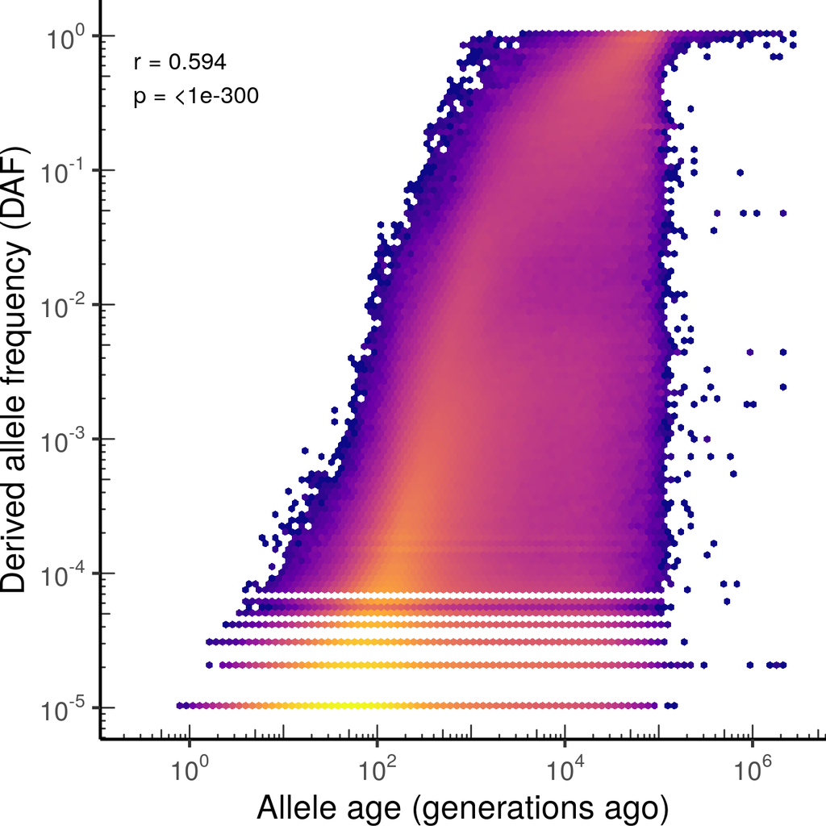

```r
mean_age_vs_freq_plot <- hex_scatter(
  ts_lf_merge |>
    filter(mutation_root_parent == FALSE),
  x = mean_time, y = AF_ts,
  xlab = "Allele age (generations ago)",
  ylab = "Derived allele frequency (DAF)",
  log_x = TRUE, log_y = TRUE,
  bins = 100,
  show_cor = TRUE, cor_method = "spearman",
  cor_label_x = -0.6, cor_label_y = -0.5,
  cor_coords = "log10",
  cor_size = 5
)
mean_age_vs_freq_plot
```

```r
ggsave(paste0(paths$plots_dir, "mean_age_vs_freq.pdf"), mean_age_vs_freq_plot, width = 7, height = 7)
```

Frequency bins

```r
ts_lf_merge %<>%
  mutate(
    frequency_bin = case_when(
      AC_ts == 1     ~ "Singletons",
      AC_ts > 1 & AF_ts <= 0.0001 ~ "< 0.0001\n(non-singleton)",
      AF_ts > 0.0001 & AF_ts <= 0.001  ~ "0.0001 - 0.001",
      AF_ts > 0.001 & AF_ts <= 0.01  ~ "0.001 - 0.01",
      AF_ts > 0.01 & AF_ts <= 0.1  ~ "0.01 - 0.1",
      AF_ts > 0.1 ~ "> 0.1"
    )
  )

order_freq_bins <-
  c(
    "Singletons",
    "< 0.0001\n(non-singleton)",
    "0.0001 - 0.001",
    "0.001 - 0.01",
    "0.01 - 0.1",
    "> 0.1"
  )
```

Tabulate statistics

```r
# Excluding mutations whose parents are unconstrained roots.
stats_per_freq_bin <- ts_lf_merge |>
  filter(mutation_root_parent == FALSE) |>
  group_by(frequency_bin) |>
  summarise(
    n_mutations         = n(),
    mean_age   = mean(mean_time, na.rm = TRUE),
    gm_age = exp(mean(log(mean_time), na.rm = TRUE)),
    median_age  = median(mean_time, na.rm = TRUE)
  ) |>
  as_tibble() |>
  mutate(
    frequency_bin = factor(frequency_bin, levels = order_freq_bins),
    percentage_of_total = 100 * (n_mutations / sum(n_mutations))
  ) |>
  arrange(frequency_bin)
knitr::kable(stats_per_freq_bin, bookends = FALSE)
```

| frequency_bin | n_mutations | mean_age | gm_age | median_age | percentage_of_total |
| --- | --- | --- | --- | --- | --- |
| Singletons | 11771739 | 107.1559 | 51.07515 | 50.41293 | 51.005859 |
| < 0.0001 |  |  |  |  |  |
| (non-singleton) | 8060795 | 404.8753 | 104.11996 | 90.97295 | 34.926681 |
| 0.0001 - 0.001 | 2054457 | 1197.7605 | 344.80267 | 256.09638 | 8.901772 |
| 0.001 - 0.01 | 602687 | 4261.1847 | 1294.72389 | 880.15816 | 2.611387 |
| 0.01 - 0.1 | 231339 | 8908.0080 | 3702.12114 | 3025.77743 | 1.002371 |
| > 0.1 | 358173 | 30074.1760 | 20931.06982 | 24527.29196 | 1.551931 |

As bar plot of mutation counts

```r
plot_freq_bar <- stats_per_freq_bin |>
  ggplot(aes(
    x = frequency_bin, y = n_mutations / 1000000
  )) +
  geom_bar(stat = "identity", fill = "#005eb8", colour = "black", width = 0.65) +
  theme_minimal(base_size = 20) +
  theme(
    panel.grid.minor = element_blank(),
    panel.grid.major.x = element_blank(),
    legend.position = "NONE",
    axis.text.x = element_text(size = 0.1, colour = "white")
  ) +
  geom_text(
    aes(label = paste0(round(percentage_of_total, 2), "%"), vjust = -0.5, size = 5)
  ) +
  labs(
    x = "",
    y = "Mutations (millions)",
    title = "GEL tree sequence"
  ) +
  scale_y_continuous(limits = c(0, 14.5))
```

As violin plot

```r
freq_bin_df <- ts_lf_merge |>
  filter(mutation_root_parent == FALSE) |>
  dplyr::select(
    mean_time, frequency_bin
  ) |>
  as_tibble() |>
  mutate(frequency_bin = factor(frequency_bin, levels = order_freq_bins))
```

```r
plot_freq_violin <- freq_bin_df |>
  ggplot(aes(x = frequency_bin, y = mean_time)) +
  geom_violin(fill = "#005eb8", colour = "black") +
  geom_point(data = stats_per_freq_bin, aes(y = gm_age),
             shape = 23, size = 5, fill = "black", colour = "black", stroke = 0.6) +
  geom_text(data = stats_per_freq_bin,
            aes(y = gm_age, label = label_comma(accuracy = 1)(gm_age)),
            size = 5, colour = "black", vjust = 2.1) +
  scale_y_log10(
    breaks = trans_breaks("log10", function(x) 10^x),
    labels = trans_format("log10", math_format(10^.x))
  ) +
  annotation_logticks(sides = "l",
                      linewidth = 0.5, colour = "grey20",
                      short = unit(0.05, "cm"),
                      mid   = unit(0.075, "cm"),
                      long  = unit(0.1, "cm")) +
  theme_minimal(base_size = 20) +
  theme(
    panel.grid.minor = element_blank(),
    panel.grid.major.x = element_blank(),
    legend.position = "none",
    axis.text.x = element_text(angle = 45, hjust = 1, vjust = 1)
  ) +
  labs(x = "Derived allele frequency bin",
       y = "Allele age (generations ago)")
```

Combine the two

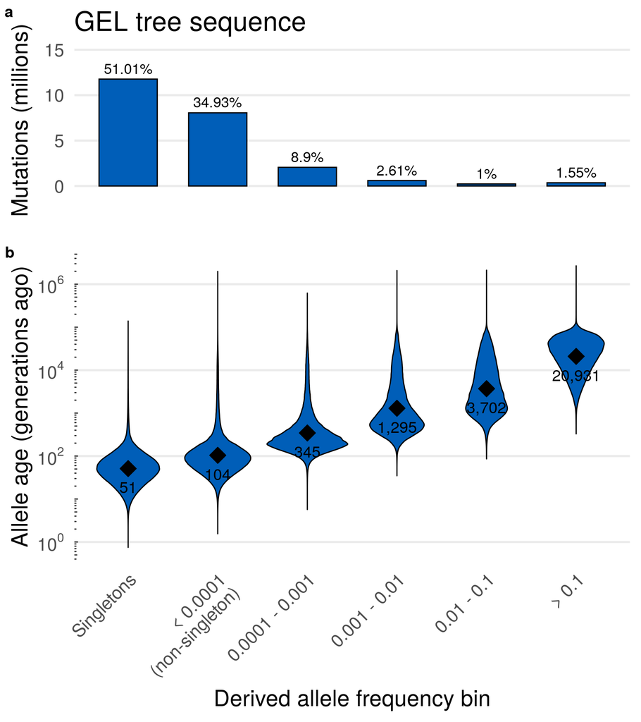

```r
plot_freq_comb<- plot_grid(
  plot_freq_bar,
  plot_freq_violin,
  align = "v",
  ncol = 1,
  labels = c("a", "b"),
  rel_heights = c(0.5, 1)
)
plot_freq_comb
```

```r
ggsave(paste0(paths$plots_dir, "freq_comb_barviolin.pdf"), plot_freq_comb, width = 8, height = 9)
```

#### 5.0.0.2 Summarise allele ages by contigs

Total independent trees + there start and end positions along chromosomes

```r
stats_per_contig <- ts_lf_merge |>
  as_tibble() |>
  group_by(ts_name) |>
  summarise(
    chromosome = min(chromosome),
    start_position = min(position),
    end_position   = max(position),
    n_mutations = n(),
    mean_age   = mean(mean_time, na.rm = TRUE),
    sd_age      = sd(mean_time, na.rm = TRUE),
    gmean_age = exp(mean(log(mean_time), na.rm = TRUE)),
    median_age  = median(mean_time, na.rm = TRUE)
  ) |>
  mutate(
    contig_size_mb    = (end_position - start_position) / 1000000
  ) |>
  arrange(ts_name) |>
  as_tibble()

knitr::kable(stats_per_contig, bookends = FALSE)
```

| ts_name | chromosome | start_position | end_position | n_mutations | mean_age | sd_age | gmean_age | median_age | contig_size_mb |
| --- | --- | --- | --- | --- | --- | --- | --- | --- | --- |
| chr16p22M~28M | chr16 | 22661538 | 28286126 | 648035 | 2069.576 | 27829.32 | 98.93876 | 73.49481 | 5.624588 |
| chr16p~15M | chr16 | 16689 | 14637672 | 2207607 | 2423.094 | 27822.75 | 134.80449 | 102.80410 | 14.620983 |
| chr17p18M | chr17 | 281784 | 18276569 | 2054169 | 2207.649 | 29489.36 | 99.53526 | 73.49991 | 17.994785 |
| chr17q36M~38M | chr17 | 36458468 | 37824094 | 148058 | 1076.007 | 15358.09 | 100.18322 | 75.54428 | 1.365626 |
| chr17q38M~45M | chr17 | 38221639 | 45432621 | 767498 | 1122.845 | 20096.44 | 96.89937 | 77.69917 | 7.210982 |
| chr17q45M~83M | chr17 | 45586151 | 83087382 | 4054897 | 1661.916 | 25408.00 | 96.21480 | 74.51528 | 37.501231 |
| chr17q~36M | chr17 | 26718757 | 36149680 | 963103 | 1341.780 | 24911.91 | 89.89811 | 71.31899 | 9.430923 |
| chr18p | chr18 | 148918 | 15357916 | 1600529 | 2274.853 | 25567.33 | 95.95935 | 70.13775 | 15.208998 |
| chr19p | chr19 | 75006 | 24174775 | 2396915 | 2090.172 | 26721.32 | 100.15296 | 75.18731 | 24.099769 |
| chr20p | chr20 | 227205 | 26274525 | 2934750 | 2013.924 | 24434.75 | 97.28690 | 72.58558 | 26.047320 |
| chr20q31M~ | chr20 | 31254980 | 64237737 | 3783587 | 1671.795 | 22295.08 | 99.53843 | 76.95647 | 32.982757 |
| chr21q34M~43M | chr21 | 34495543 | 42960010 | 988743 | 2595.728 | 31635.54 | 101.96042 | 73.14264 | 8.464467 |
| chr21q44M~47M | chr21 | 44253397 | 46680226 | 304942 | 2585.009 | 40425.85 | 124.00116 | 90.26739 | 2.426829 |
| chr22q16M~18M | chr22 | 16439646 | 18110684 | 147455 | 2227.795 | 33436.00 | 85.78205 | 60.83774 | 1.671038 |
| chr22q19M~21M | chr22 | 18897685 | 21045540 | 223988 | 1766.815 | 24579.67 | 100.90766 | 74.49679 | 2.147855 |

#### 5.0.0.3 Genomic representativeness of contigs

We want to compare our contigs to genome in terms of: - Genic fractions  
- Recombination rates

Inference regions CSV

```r
inference_regions <- read_csv("../data/inference_regions.csv")
```

Regions

```r
regions_table <- stats_per_contig %>%
  dplyr::select(ts_name, chromosome, start_position, end_position)
regions_gr <- with(regions_table,
  GRanges(
    seqnames = chromosome,
    ranges   = IRanges(start = start_position, end = end_position)
  )
)
region_lengths <- width(regions_gr)
```

Read in the ensembl gene layers (genome-wide)

```r
ensembl_genes <- readGFF(paths$genes_ensembl) %>%
  mutate(chromosome = paste0("chr", seqid))
```

```r
autosomes <- paste0("chr", seq(1:22))
genes_gr <- ensembl_genes %>%
  filter(type == "gene", gene_biotype == "protein_coding") %>%
  transmute(
    seqnames = chromosome,
    start    = start,
    end      = end
  ) %>%
  distinct() %>%   # just in case of duplicates
  { GRanges(seqnames = .$seqnames, ranges = IRanges(start = .$start, end = .$end)) }
genes_union <- reduce(genes_gr)
genes_union <- keepSeqlevels(genes_gr,        autosomes, pruning.mode = "coarse")
genes_cov <- coverage(genes_union)
```

Functions for extracting or summarising genic proportions

```r
prop_bases_in_genes <- function(regions_gr, feature_gr) {
  regions_union <- reduce(regions_gr)
  ov <- intersect(regions_union, feature_gr)
  sum(width(ov)) / sum(width(regions_union))
}

prop_bases_in_genes_summary <- function(regions_gr, feature_cov) {

  chroms <- as.character(seqnames(regions_gr))
  starts <- start(regions_gr)
  ends   <- end(regions_gr)
  len_bp <- ends - starts + 1L

  n <- length(chroms)
  feature_bp <- numeric(n)

  # For each region, sum coverage over that interval
  for (i in seq_len(n)) {
    cov_chr <- feature_cov[[chroms[i]]]
    if (is.null(cov_chr)) {
      feature_bp[i] <- 0
    } else {
      v <- Views(cov_chr, starts[i], ends[i])
      feature_bp[i] <- sum(viewSums(v))
    }
  }

  prop_region <- round(feature_bp / len_bp, 3)

  total_feature_bp <- sum(feature_bp)
  total_bp         <- sum(len_bp)
  overall_prop     <- total_feature_bp / total_bp

  per_region <- tibble::tibble(
    chromosome        = chroms,
    start_position        = starts,
    end_position          = ends,
    len_bp       = len_bp,
    feature_bp   = feature_bp,
    prop_feature = prop_region
  )

  list(
    total_feature_bp = total_feature_bp,
    total_bp         = total_bp,
    overall_prop     = overall_prop,
    per_region       = per_region
  )
}
```

Summarise for the data

```r
gene_summary_obs <- prop_bases_in_genes_summary(regions_gr, genes_cov)
gene_summary_obs
```

```
## $total_feature_bp
## [1] 124161847
##
## $total_bp
## [1] 206798166
##
## $overall_prop
## [1] 0.6004011
##
## $per_region
## # A tibble: 15 × 6
##    chromosome start_position end_position   len_bp feature_bp prop_feature
##    <chr>               <int>        <int>    <int>      <dbl>        <dbl>
##  1 chr16            22661538     28286126  5624589    2988768        0.531
##  2 chr16               16689     14637672 14620984   10413615        0.712
##  3 chr17              281784     18276569 17994786   11890245        0.661
##  4 chr17            36458468     37824094  1365627     863849        0.633
##  5 chr17            38221639     45432621  7210983    4639321        0.643
##  6 chr17            45586151     83087382 37501232   22291677        0.594
##  7 chr17            26718757     36149680  9430924    6315885        0.67
##  8 chr18              148918     15357916 15208999    7279708        0.479
##  9 chr19               75006     24174775 24099770   17205529        0.714
## 10 chr20              227205     26274525 26047321   12683421        0.487
## 11 chr20            31254980     64237737 32982758   17269846        0.524
## 12 chr21            34495543     42960010  8464468    6143876        0.726
## 13 chr21            44253397     46680226  2426830    1703573        0.702
## 14 chr22            16439646     18110684  1671039     936046        0.56
## 15 chr22            18897685     21045540  2147856    1536488        0.715
```

HapMap recombination rates (genome-wide)

```r
hapmap_rates_list <- list()
for (chrom in paste0("chr", seq(1:22))) {
  hapmap_rates_list[[chrom]] <- read_tsv(
    paste0("/public_data_resources/recomb_hg38/genetic_map_GRCh38_", chrom, ".txt")
  )
}
hapmap_rates <- do.call(rbind, hapmap_rates_list)
hapmap_rates <- hapmap_rates %>%
  dplyr::arrange(chrom, pos)

hapmap_by_chr <- split(hapmap_rates, hapmap_rates$chrom)
```

```r
compute_recomb_summary <- function(regions_gr, hapmap_by_chr) {

  chroms <- as.character(seqnames(regions_gr))
  starts <- start(regions_gr)
  ends   <- end(regions_gr)
  len_bp <- ends - starts + 1L

  n <- length(chroms)
  cm_start <- numeric(n)
  cm_end   <- numeric(n)

  for (i in seq_len(n)) {
    map_chr <- hapmap_by_chr[[chroms[i]]]
    if (is.null(map_chr)) {
      cm_start[i] <- NA_real_
      cm_end[i]   <- NA_real_
    } else {
      cm_start[i] <- approx(map_chr$pos, map_chr$pos_cm,
                            xout = starts[i], rule = 2)$y
      cm_end[i]   <- approx(map_chr$pos, map_chr$pos_cm,
                            xout = ends[i],   rule = 2)$y
    }
  }

  cm_span <- cm_end - cm_start
  rate_cM_Mb <- round(cm_span / (len_bp / 1e6), 3)

  total_cm     <- sum(cm_span, na.rm = TRUE)
  total_bp     <- sum(len_bp, na.rm = TRUE)
  overall_rate <- total_cm / (total_bp / 1e6)

  per_region <- tibble::tibble(
    chromosome      = chroms,
    start_position      = starts,
    end_position        = ends,
    len_bp     = len_bp,
    cm_start   = cm_start,
    cm_end     = cm_end,
    cm_span    = cm_span,
    rate_cM_Mb = rate_cM_Mb
  )

  list(
    total_cm     = total_cm,
    total_bp     = total_bp,
    overall_rate = overall_rate,
    per_region   = per_region
  )
}
```

Summarise recomb rates for regions

```r
obs_rec <- compute_recomb_summary(regions_gr, hapmap_by_chr)
obs_rec
```

```
## $total_cm
## [1] 401.5722
##
## $total_bp
## [1] 206798166
##
## $overall_rate
## [1] 1.941856
##
## $per_region
## # A tibble: 15 × 8
##    chromosome start_position end_position   len_bp cm_start cm_end cm_span
##    <chr>               <int>        <int>    <int>    <dbl>  <dbl>   <dbl>
##  1 chr16            22661538     28286126  5624589   43.9    56.5    12.6
##  2 chr16               16689     14637672 14620984    0      32.7    32.7
##  3 chr17              281784     18276569 17994786    0.655  43.6    43.0
##  4 chr17            36458468     37824094  1365627   57.8    60.6     2.81
##  5 chr17            38221639     45432621  7210983   61.1    67.1     6.01
##  6 chr17            45586151     83087382 37501232   67.2   128.     61.3
##  7 chr17            26718757     36149680  9430924   46.5    57.3    10.8
##  8 chr18              148918     15357916 15208999    0.258  40.2    39.9
##  9 chr19               75006     24174775 24099770    0      49.3    49.3
## 10 chr20              227205     26274525 26047321    0.159  51.0    50.8
## 11 chr20            31254980     64237737 32982758   51.0   108.     57.2
## 12 chr21            34495543     42960010  8464468   37.2    56.5    19.3
## 13 chr21            44253397     46680226  2426830   58.6    62.8     4.16
## 14 chr22            16439646     18110684  1671039    1.69    7.09    5.40
## 15 chr22            18897685     21045540  2147856    8.91   15.3     6.40
## # ℹ 1 more variable: rate_cM_Mb <dbl>
```

Tabulate Region chr20q31M~64M requires renaming

```r
regions_edit <- regions_table %>%
  left_join(gene_summary_obs$per_region, by = c("chromosome", "start_position", "end_position")) %>%
  left_join(obs_rec$per_region, by = c("chromosome", "start_position", "end_position")) %>%
  dplyr::select(ts_name, prop_feature, rate_cM_Mb) %>%
  mutate(ts_name = ifelse(ts_name == "chr20q31M~", "chr20q31M~64M", ts_name))
colnames(regions_edit) <- c("region_name", "genic_proportion", "recomb_rate_cM_Mb")

inference_regions %>%
  left_join(regions_edit) %>%
  as.data.frame() %>%
  mutate(
    genic_proportion = ifelse(region_name == "Total", round(gene_summary_obs$overall_prop,3), genic_proportion),
    recomb_rate_cM_Mb = ifelse(region_name == "Total", round(obs_rec$overall_rate,3), recomb_rate_cM_Mb)
  ) %>%
  write_csv("../data/inference_regions_expanded.csv")
```

Chromosome sizes (for random sampling)

```r
fasta_template <- config$paths$fasta_ancestor
chrom_nums <- 1:22
fasta_paths <- glue(fasta_template, chrom_no_prefix = chrom_nums)
fai_paths   <- paste0(fasta_paths, ".fai")
chrom_sizes <- purrr::map_dfr(seq_along(chrom_nums), function(i) {
  read_tsv(
    fai_paths[i],
    col_names = c("name", "length", "offset", "line_bases", "line_width"),
    col_types = "cniii"
  ) %>%
    # Each ancestor FASTA is per chromosome, so this should be a single row;
    # we use our known chr number to standardise the name.
    transmute(
      chromosome = paste0("chr", chrom_nums[i]),
      length = length
    )
})
```

Get the autosomal regions lengths

```r
genome_autosomes <- GRanges(
  seqnames = chrom_sizes$chromosome,
  ranges   = IRanges(start = 1L, end = chrom_sizes$length)
)
```

Callable genome only? Excluding assembly gaps.

```r
cyto <- read_tsv(
  paths$cytoband,
  col_names = c("chromosome", "start", "end", "band", "stain")
)

centromeres_gr <- cyto %>%
  filter(
    stain %in% c("acen", "gvar")
  ) %>%
  transmute(seqnames = chromosome,
            start    = start,
            end      = end) %>%
  { GRanges(seqnames = .$seqnames,
            ranges   = IRanges(start = .$start + 1, end = .$end)) } %>%  # BED→GRanges
  reduce()

gaps_df <- readr::read_tsv(
  paths$gaps,
  col_names = c("bin", "chromosome", "start", "end",
                "ix", "n", "size", "type", "bridge")
)

gaps_gr <- gaps_df %>%
  filter(chromosome %in% paste0("chr", 1:22)) %>%
  mutate(
    # gap.txt is 0-based start, 1-based end → convert to GRanges:
    start = start + 1L
  ) %>%
  transmute(
    seqnames = chromosome,
    start,
    end
  ) %>%
  { GRanges(seqnames = .$seqnames,
            ranges   = IRanges(start = .$start, end = .$end)) } %>%
  reduce()
```

Get only autosomal regions without gaps (to sample from)

```r
autosomes <- chrom_sizes$chromosome   # e.g. "chr1".."chr22"
centromeres_gr <- keepSeqlevels(centromeres_gr, autosomes, pruning.mode = "coarse")
gaps_gr        <- keepSeqlevels(gaps_gr,        autosomes, pruning.mode = "coarse")

bad_regions_gr <- reduce(c(centromeres_gr, gaps_gr))
good_regions_gr <- GenomicRanges::setdiff(genome_autosomes, bad_regions_gr)
good_regions_gr <- good_regions_gr[width(good_regions_gr) > 0]
```

```r
feature_content_in_callable <- function(callable_gr, feature_cov) {

  chroms <- as.character(seqnames(callable_gr))
  starts <- start(callable_gr)
  ends   <- end(callable_gr)
  len_bp <- ends - starts + 1L

  n <- length(chroms)
  feature_bp <- numeric(n)

  for (i in seq_len(n)) {
    cov_chr <- feature_cov[[chroms[i]]]
    if (is.null(cov_chr)) {
      feature_bp[i] <- 0
    } else {
      v <- Views(cov_chr, starts[i], ends[i])
      feature_bp[i] <- sum(viewSums(v))
    }
  }

  total_callable_bp <- sum(len_bp)
  total_feature_bp  <- sum(feature_bp)
  overall_prop      <- total_feature_bp / total_callable_bp

  list(
    total_feature_bp  = total_feature_bp,
    total_callable_bp = total_callable_bp,
    overall_prop      = overall_prop
  )
}
```

```r
gene_content_callable <- feature_content_in_callable(good_regions_gr, genes_cov)
gene_content_callable
```

```
## $total_feature_bp
## [1] 1311428918
##
## $total_callable_bp
## [1] 2652063523
##
## $overall_prop
## [1] 0.4944938
```

Total callable genome

```r
rec_callable <- compute_recomb_summary(good_regions_gr, hapmap_by_chr)
rec_callable
```

```
## $total_cm
## [1] 3515.059
##
## $total_bp
## [1] 2652063523
##
## $overall_rate
## [1] 1.325405
##
## $per_region
## # A tibble: 164 × 8
##    chromosome start_position end_position   len_bp cm_start  cm_end cm_span
##    <chr>               <int>        <int>    <int>    <dbl>   <dbl>   <dbl>
##  1 chr1                10001       207666   197666    0       0.303  0.303
##  2 chr1               257667       297968    40302    0.391   0.478  0.0870
##  3 chr1               347969       535988   188020    0.629   1.20   0.568
##  4 chr1               585989      2702781  2116793    1.35    5.23   3.88
##  5 chr1              2746291     12954384 10208094    5.23   27.3   22.0
##  6 chr1             13004385     16799163  3794779   27.3    35.5    8.24
##  7 chr1             16849164     29552233 12703070   35.5    54.0   18.5
##  8 chr1             29553836    121700000 92146165   54.0   151.    96.8
##  9 chr1            143200001    223558935 80358935  156.    242.    86.4
## 10 chr1            223608936    228558364  4949429  242.    245.     2.74
## # ℹ 154 more rows
## # ℹ 1 more variable: rate_cM_Mb <dbl>
```

Precompute the list of possible regions to subsample from

```r
precompute_good_regions <- function(good_regions_gr, len) {
  w <- width(good_regions_gr)
  starts_per_region <- pmax(w - len + 1L, 0L)

  keep <- starts_per_region > 0L

  list(
    regions          = good_regions_gr[keep],
    starts_per_region = as.numeric(starts_per_region[keep]),  # numeric avoids int overflow
    n_regions        = sum(keep)
  )
}

len_levels <- sort(unique(region_lengths))

precomp_list <- lapply(
  len_levels,
  function(len) precompute_good_regions(good_regions_gr, len)
)
names(precomp_list) <- as.character(len_levels)
```

```r
sample_one_region <- function(len, precomp) {
  if (precomp$n_regions == 0L) {
    stop("No good regions long enough to place length ", len)
  }

  # Pick a region, weighted by how many valid starts it contains
  region_idx <- sample.int(
    precomp$n_regions,
    size = 1L,
    prob = precomp$starts_per_region
  )

  region       <- precomp$regions[region_idx]
  n_pos        <- precomp$starts_per_region[region_idx]
  region_start <- start(region)

  # Sample a start offset within that region
  offset_in_region <- sample.int(n_pos, 1L) - 1L
  start_pos        <- region_start + offset_in_region
  end_pos          <- start_pos + len - 1L

  GRanges(seqnames = seqnames(region),
          ranges   = IRanges(start_pos, end_pos))
}

sample_random_regions <- function(region_lengths, precomp_list) {
  regs <- vector("list", length(region_lengths))

  for (i in seq_along(region_lengths)) {
    len  <- region_lengths[i]
    info <- precomp_list[[as.character(len)]]
    regs[[i]] <- sample_one_region(len, info)
  }

  do.call(c, regs)
}
```

Test a selection of sampled regions of same lengths

```r
rand_test_regions <- sample_random_regions(region_lengths, precomp_list)
gene_summary_rand_test <- prop_bases_in_genes_summary(rand_test_regions,  genes_cov)
gene_summary_rand_test
```

```
## $total_feature_bp
## [1] 86364013
##
## $total_bp
## [1] 206798166
##
## $overall_prop
## [1] 0.4176247
##
## $per_region
## # A tibble: 15 × 6
##    chromosome start_position end_position   len_bp feature_bp prop_feature
##    <chr>               <int>        <int>    <int>      <dbl>        <dbl>
##  1 chr10            86034278     91658866  5624589    2942232        0.523
##  2 chr3            117579126    132200109 14620984    9939574        0.68
##  3 chr6             19627005     37621790 17994786    7855981        0.437
##  4 chr7             63691852     65057478  1365627     399943        0.293
##  5 chr15            27950941     35161923  7210983    4734089        0.657
##  6 chr13            47206449     84707680 37501232    8035570        0.214
##  7 chr7              9953917     19384840  9430924    4806439        0.51
##  8 chr2             48871873     64080871 15208999    6354956        0.418
##  9 chr4            154898547    178998316 24099770    9084222        0.377
## 10 chr8             13104224     39151544 26047321   12927883        0.496
## 11 chr5             89297674    122280431 32982758   10712097        0.325
## 12 chr3             21568913     30033380  8464468    6454097        0.762
## 13 chr11            42626011     45052840  2426830     948845        0.391
## 14 chr2            159500869    161171907  1671039     926076        0.554
## 15 chr6             48339162     50487017  2147856     242009        0.113
```

Run for 100 replicates

```r
set.seed(42)
n_iter <- 100L
```

Iterate for 100 random draws of same region lengths

```r
rand_props <- replicate(n_iter, {
    rand_regions <- sample_random_regions(region_lengths, precomp_list)
    prop_bases_in_genes(rand_regions, genes_union)
  })
```

```r
gene_summary_obs$overall_prop
```

```
## [1] 0.6004011
```

```r
summary(rand_props)
```

```
##    Min. 1st Qu.  Median    Mean 3rd Qu.    Max.
##  0.3927  0.4521  0.4681  0.4703  0.4886  0.5332
```

```r
p_gene <- plot_obs_vs_random(
  random_values = rand_props,
  observed_value = gene_summary_obs$overall_prop,
  title = "Gene Content",
  xlab  = "Proportion of bases in genes"
)
```

```r
len <- region_lengths[[1]]
rand_region <- sample_one_region(len, precomp_list[[as.character(len)]])

prop_bases_in_genes(rand_region, genes_union)
```

```
## [1] 0.588211
```

```r
compute_recomb_summary(rand_region, hapmap_by_chr)$overall_rate
```

```
## [1] 0.8957008
```

Get overall rates from random sample of recombination rates

```r
rand_rates <- replicate(n_iter, {
    rand_regions <- sample_random_regions(region_lengths, precomp_list)
    compute_recomb_summary(rand_regions, hapmap_by_chr)$overall_rate
  })
```

Compare ours to the random samples?

```r
obs_rec$overall_rate
```

```
## [1] 1.941856
```

```r
summary(rand_rates)
```

```
##    Min. 1st Qu.  Median    Mean 3rd Qu.    Max.
##   0.926   1.067   1.120   1.134   1.208   1.354
```

```r
p_rec <- plot_obs_vs_random(
  random_values = rand_rates,
  observed_value = obs_rec$overall_rate,
  title = "Recombination Rate",
  xlab  = "Recombination rate (cM/Mb)"
)
```

Function to calculate the mean of Relate Age estimates in a specified list of regions

```r
relate_age_summary <- function(regions_gr, csv_path=paths$relate_ages_csv) {
  chroms <- as.character(seqnames(regions_gr))
  regions_dt <- data.table(
    chr = chroms,
    start = start(regions_gr),
    end = end(regions_gr),
    len_bp = width(regions_gr),
    region_id = seq_along(regions_gr)
  )

  setkey(regions_dt, chr, start, end)
  relate_dt <- fread(cmd = paste("zstd -dc", shQuote(csv_path)))
  relate_dt[, chr := paste0("chr", as.character(chr))]
  relate_dt[, `:=`(start = pos_hg38, end = pos_hg38)]
  setkey(relate_dt, chr, start, end)
  hits <- foverlaps(relate_dt, regions_dt, by.x = c("chr", "start", "end"),
                    by.y = c("chr", "start", "end"), nomatch = 0L)
  means_per_region <- hits[, .(mean_age = mean(age)), by = region_id]
  per_region <- regions_dt[means_per_region, on = "region_id"]
  overall_mean <- with(per_region, sum(len_bp * mean_age) / sum(len_bp))
  list(
    overall_mean = overall_mean,
    per_region = per_region[, .(chromosome = chr, start_position = start,
                                end_position = end, len_bp, mean_age)]
  )
}
```

Compute Relate age means for 100 random region sets and the observed regions and store. This requires a dataset too large to include in the repository, which was constructed using tgp_comparison/region_evaluation.py.

```r
random_relate_means <- replicate(n_iter, {
    rand_regions <- sample_random_regions(region_lengths, precomp_list)
    relate_age_summary(rand_regions)$overall_mean
  })
obs_relate_means <- relate_age_summary(regions_gr)

df_out <- dplyr::bind_rows(
  tibble::tibble(type = "random",   overall_mean = random_relate_means),
  tibble::tibble(type = "observed", overall_mean = obs_relate_means$overall_mean)
)
readr::write_csv(df_out, paths$relate_means_csv)
```

Extract the mean age data and plot (works with data included in this repository)

```r
df <- readr::read_csv(paths$relate_means_csv)
random_values <- df$overall_mean[df$type == "random"]
observed_value <- df$overall_mean[df$type == "observed"][1]

p_relate <- plot_obs_vs_random(
  random_values = random_values,
  observed_value = observed_value,
  title = "Relate age estimates",
  xlab  = "Mean Allele age (generations ago)"
)
```

Combine and plot

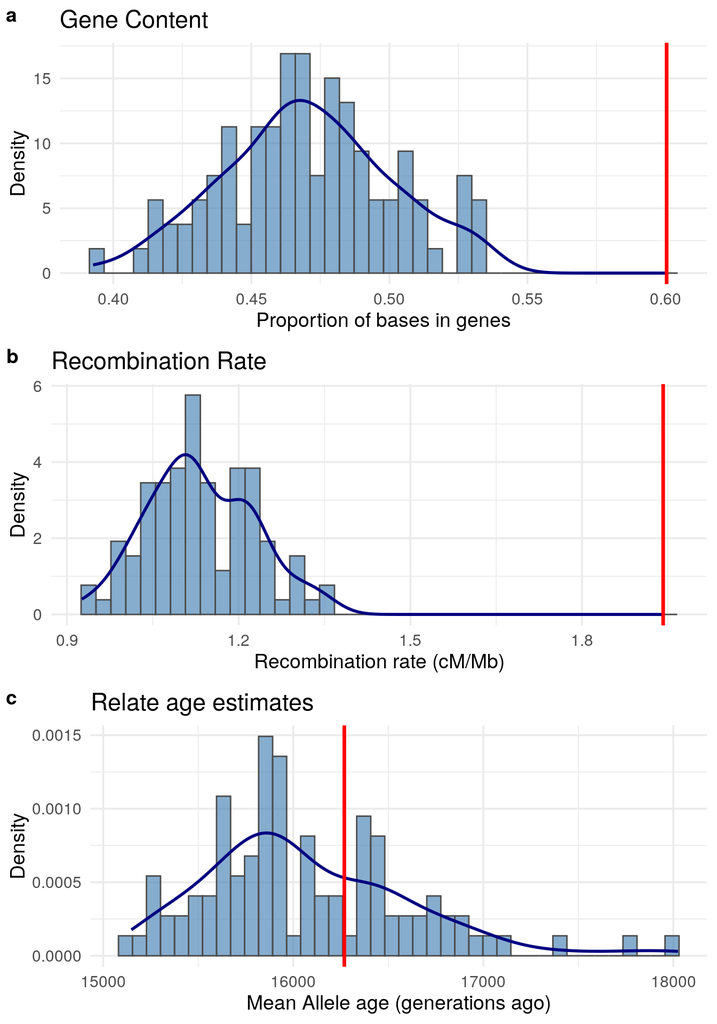

```r
comb_random_plot <- ggarrange(
  p_gene, p_rec, p_relate, nrow = 3,
  labels = c("a", "b", "c")
)
comb_random_plot
```

```r
ggsave(paste0(paths$plots_dir, "genic_and_recomb_vs_random.pdf"), comb_random_plot, width = 7, height = 7)
```

#### 5.0.0.4 Summarise allele ages by consequence category

VEP should encode most severe as 1st in order…

```r
ts_lf_merge %<>%
  mutate(
    consequence = ifelse(is.na(consequence), "intergenic_variant", consequence)
  ) %>%
  separate(consequence, sep = ",", into = c("tmp1", "tmp2"))  %>%
  # split ampersand-delimited sub-terms too
  separate(tmp1, sep = "&", into = c("consequence_new", "tmp12"))  %>%
  dplyr::select(-contains("tmp"))  %>%
  mutate(
    consequence_cat = case_when(
      consequence_new %in% c("start_lost", "stop_lost", "stop_gained") ~ "Protein-truncating",
      consequence_new %in% c("splice_acceptor_variant", "splice_donor_variant") ~ "Splice-altering",
      consequence_new == "missense_variant" ~ "Missense",
      consequence_new %in% c("splice_region_variant", "splice_polypyrimidine_tract_variant") ~ "Splice-region",
      consequence_new == "synonymous_variant" ~ "Synonymous",
      consequence_new == "intergenic_variant" ~ "Non-coding"
    )
  )

order_consq_cats <-
  c(
    "Non-coding",
    "Synonymous",
    "Splice-region",
    "Missense",
    "Protein-truncating",
    "Splice-altering"
  )
```

Tabulate statistics

```r
stats_per_consq <- ts_lf_merge |>
  as_tibble() |>
  filter(mutation_root_parent == FALSE) |>
  group_by(consequence_cat) |>
  summarise(
    n_mutations = n(),
    mean_age   = mean(mean_time, na.rm = TRUE),
    sd_age      = sd(mean_time, na.rm = TRUE),
    gm_age = exp(mean(log(mean_time), na.rm = TRUE)),
    median_age  = median(mean_time, na.rm = TRUE)
  ) |>
  as_tibble() |>
  mutate(
    consequence_cat = factor(consequence_cat, levels = order_consq_cats),
    percentage_of_total = 100 * (n_mutations / sum(n_mutations))
  ) |>
  arrange(consequence_cat)
knitr::kable(stats_per_consq, bookends = FALSE)
```

| consequence_cat | n_mutations | mean_age | sd_age | gm_age | median_age | percentage_of_total |
| --- | --- | --- | --- | --- | --- | --- |
| Non-coding | 22517141 | 983.0617 | 6000.167 | 97.08528 | 76.09311 | 97.5646936 |
| Synonymous | 180982 | 597.3190 | 3298.123 | 100.29511 | 83.37080 | 0.7841783 |
| Splice-region | 29614 | 508.7964 | 3031.284 | 89.69985 | 76.51544 | 0.1283147 |
| Missense | 336127 | 370.0983 | 2392.389 | 80.83285 | 72.09361 | 1.4564073 |
| Protein-truncating | 9994 | 227.8869 | 1576.939 | 63.45282 | 59.70130 | 0.0433031 |
| Splice-altering | 5332 | 164.0796 | 1467.493 | 57.77488 | 55.47679 | 0.0231031 |

As bar plot of allele counts

```r
plot_consq_bar <- stats_per_consq |>
  ggplot(aes(
    x = consequence_cat, y = n_mutations / 1000000
  )) +
  geom_bar(stat = "identity", fill = "#005eb8", colour = "black", width = 0.5) +
  theme_minimal(base_size = 20) +
  theme(
    panel.grid.minor = element_blank(),
    panel.grid.major.x = element_blank(),
    legend.position = "NONE",
    axis.text.x = element_text(size = 0.1, colour = "white")
  ) +
  geom_text(
    aes(label = paste0(round(percentage_of_total, 2), "%"), vjust = -0.5, size = 5)
  ) +
  labs(
    x = "",
    y = "Mutations (millions)",
  ) +
  scale_y_continuous(limits = c(0, 25))
```

As violin plot (with point at geometric mean)

```r
consq_cat_df <- ts_lf_merge |>
  filter(mutation_root_parent == FALSE) |>
  dplyr::select(
    mean_time, consequence_cat
  ) |>
  as_tibble() |>
  mutate(consequence_cat = factor(consequence_cat, levels = order_consq_cats))
```

```r
plot_consq_violin <- consq_cat_df |>
  ggplot(aes(x = consequence_cat, y = mean_time)) +
  geom_violin(fill = "#005eb8", colour = "black") +
  # point at geometric mean
  geom_point(data = stats_per_consq, aes(y = gm_age),
             shape = 23, size = 5, fill = "black", colour = "black", stroke = 0.6) +
  geom_text(data = stats_per_consq, aes(y = gm_age, label = label_comma(accuracy = 1)(gm_age)),
            size = 5, colour = "black", vjust = 2.1) +
  scale_y_log10( breaks = trans_breaks("log10", function(x) 10^x), labels = trans_format("log10", math_format(10^.x)) ) +
  annotation_logticks(sides = "l") +
  theme_minimal(base_size = 20) +
  theme(
    panel.grid.minor = element_blank(),
    panel.grid.major.x = element_blank(),
    legend.position = "none",
    axis.text.x = element_text(angle = 45, hjust = 1, vjust = 1)
  ) +
  labs(x = "Consequence", y = "Allele age (generations ago)")
```

Combine the two

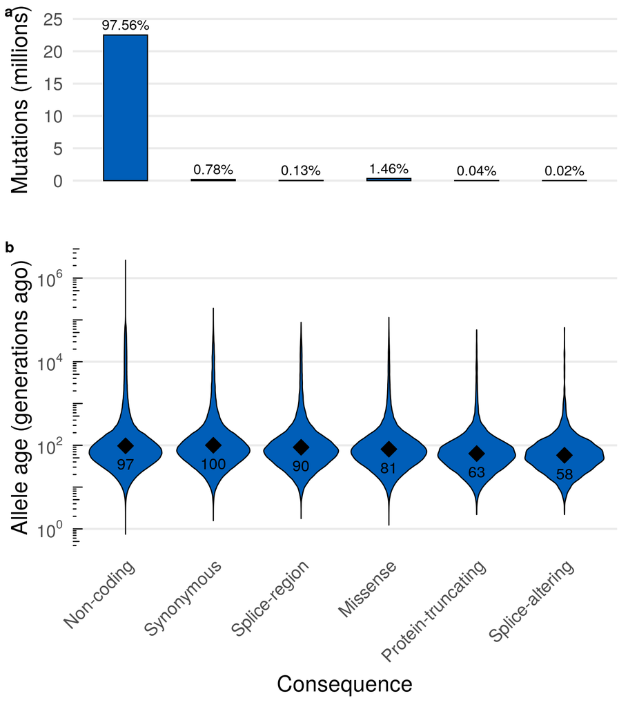

```r
plot_consq_comb <- plot_grid(
  plot_consq_bar,
  plot_consq_violin,
  align = "v",
  ncol = 1,
  labels = c("a", "b"),
  rel_heights = c(0.5, 1)
)
plot_consq_comb
```

```r
ggsave(paste0(paths$plots_dir, "consq_comb_violinbar.pdf"), plot_consq_comb, width = 8, height = 9)
```

As bar plot of “average” mutation ages (as in Fu et al. 2012, Figure 1) - The non-log transformed scales + mean makes the differences far more apparent here.

```r
mean_cl_t <- function(y){
  y <- y[is.finite(y)]
  n <- length(y); m <- mean(y); se <- sd(y)/sqrt(n)
  t <- qt(0.975, df = n - 1)
  data.frame(y = m, ymin = m - t*se, ymax = m + t*se)
}
```

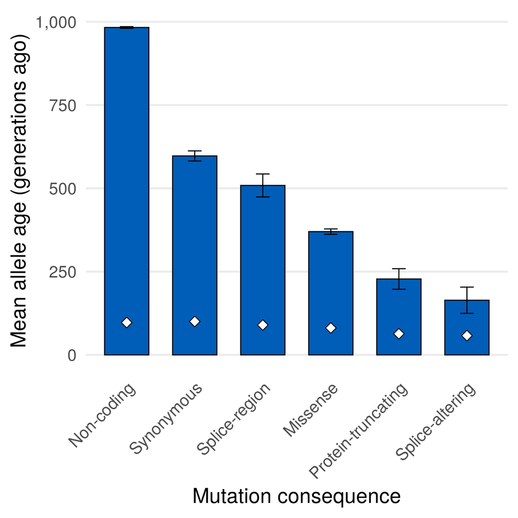

```r
mean_consq_bar <- ggplot(consq_cat_df,aes(x = consequence_cat, y = mean_time)) +
  stat_summary(fun = mean, geom = "col", fill = "#005eb8", colour = "black", width = 0.65) +
  stat_summary(fun.data = mean_cl_t, geom = "errorbar", width = 0.2) +
  scale_y_continuous(labels = label_comma()) +
  labs(x = "Mutation consequence",
       y = "Mean allele age (generations ago)") +
  theme_minimal(base_size = 20) +
  geom_point(data = stats_per_consq, aes(y = gm_age), shape = 23, size = 3.5,
             fill = "white", colour = "black", stroke = 0.6) +
  theme(
    panel.grid.minor = element_blank(),
    panel.grid.major.x = element_blank(),
    legend.position = "none",
    axis.text.x = element_text(angle = 45, hjust = 1, vjust = 1)
  )
mean_consq_bar
```

```r
ggsave(paste0(paths$plots_dir, "mean_age_consq_bar.pdf"), mean_consq_bar, width = 7, height = 7)
```

#### 5.0.0.5 Age vs edge span

Age vs edge span plot

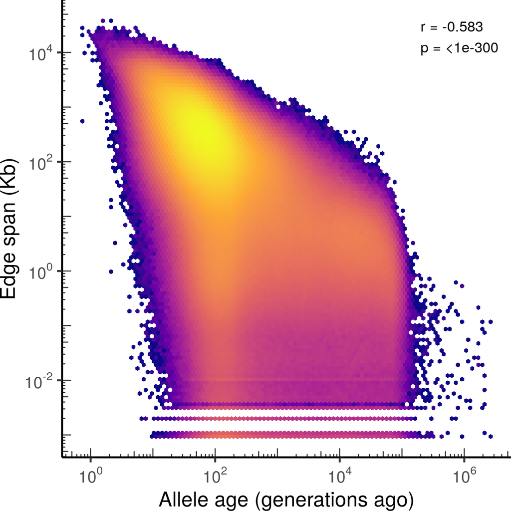

```r
mean_age_vs_edge_plot <- hex_scatter(
  ts_lf_merge |>
    filter(mutation_root_parent == FALSE),
  x = mean_time, y = edge_span_kb,
  xlab = "Allele age (generations ago)",
  ylab = "Edge span (Kb)",
  log_x = TRUE, log_y = TRUE,
  bins = 100,
  show_cor = TRUE, cor_method = "spearman",
  cor_label_x = 5.3, cor_label_y = 4,
  cor_coords = "log10",
  cor_size = 5
)
mean_age_vs_edge_plot
```

```r
ggsave(paste0(paths$plots_dir, "mean_age_vs_edge.pdf"), mean_age_vs_edge_plot, width = 7, height = 7)
```

#### 5.0.0.6 Child and parent node time variance…

Use coefficient of variation.

```r
cv_summary <- ts_lf_merge %>%
  dplyr::select(child_node_mean_time, child_node_var_time,
                parent_node_var_time, parent_node_mean_time) %>%
  as_tibble() %>%
  mutate(
    child_cv  = ifelse(child_node_mean_time  > 0 & child_node_var_time  > 0,
                       sqrt(child_node_var_time)  / child_node_mean_time,  NA_real_),
    parent_cv = ifelse(parent_node_mean_time > 0 & parent_node_var_time > 0,
                       sqrt(parent_node_var_time) / parent_node_mean_time, NA_real_),
    child_lcv  = log1p(child_cv),
    parent_lcv = log1p(parent_cv)
  ) %>%
  summarise(
    # child
    n_child              = sum(!is.na(child_cv)),
    median_cv_child      = median(child_cv, na.rm = TRUE),
    iqr_cv_child         = IQR(child_cv, na.rm = TRUE),
    mean_cv_child        = mean(child_cv, na.rm = TRUE),
    sd_cv_child          = sd(child_cv, na.rm = TRUE),
    p95_cv_child         = as.numeric(quantile(child_cv, 0.95, na.rm = TRUE, names = FALSE)),
    p99_cv_child         = as.numeric(quantile(child_cv, 0.99, na.rm = TRUE, names = FALSE)),
    max_cv_child         = max(child_cv, na.rm = TRUE),
    median_log_cv_child  = median(child_lcv, na.rm = TRUE),
    mad_log_cv_child     = mad(child_lcv, constant = 1, na.rm = TRUE),

    # parent
    n_parent             = sum(!is.na(parent_cv)),
    median_cv_parent     = median(parent_cv, na.rm = TRUE),
    iqr_cv_parent        = IQR(parent_cv, na.rm = TRUE),
    mean_cv_parent       = mean(parent_cv, na.rm = TRUE),
    sd_cv_parent         = sd(parent_cv, na.rm = TRUE),
    p95_cv_parent        = as.numeric(quantile(parent_cv, 0.95, na.rm = TRUE, names = FALSE)),
    p99_cv_parent        = as.numeric(quantile(parent_cv, 0.99, na.rm = TRUE, names = FALSE)),
    max_cv_parent        = max(parent_cv, na.rm = TRUE),
    median_log_cv_parent = median(parent_lcv, na.rm = TRUE),
    mad_log_cv_parent    = mad(parent_lcv, constant = 1, na.rm = TRUE)
  )

cv_summary_long <- cv_summary %>%
  pivot_longer(
    cols = ends_with("_child") | ends_with("_parent"),
    names_to = c("stat", "node"),
    names_sep = "_(?=[^_]+$)",
    values_to = "value"
  ) %>%
  pivot_wider(
    names_from = stat,
    values_from = value
  )
knitr::kable(cv_summary_long)
```

| node | n | median_cv | iqr_cv | mean_cv | sd_cv | p95_cv | p99_cv | max_cv | median_log_cv | mad_log_cv |
| --- | --- | --- | --- | --- | --- | --- | --- | --- | --- | --- |
| child | 11445983 | 0.4257102 | 0.5157683 | 0.4316708 | 0.2664821 | 0.8224069 | 0.9171337 | 1.766093 | 0.3546701 | 0.1782268 |
| parent | 23224276 | 0.1179713 | 0.1473228 | 0.1626629 | 0.1459481 | 0.4255581 | 0.6021744 | 1.758092 | 0.1115157 | 0.0566910 |

Just for the mutations below the root…

```r
cv_summary_root <- ts_lf_merge %>%
  filter(mutation_root_parent) %>%
  dplyr::select(child_node_mean_time, child_node_var_time,parent_node_var_time, parent_node_mean_time) %>%
  as_tibble() %>%
  mutate(
    child_cv  = ifelse(child_node_mean_time  > 0 & child_node_var_time  > 0,
                       sqrt(child_node_var_time)  / child_node_mean_time,  NA_real_),
    parent_cv = ifelse(parent_node_mean_time > 0 & parent_node_var_time > 0,
                       sqrt(parent_node_var_time) / parent_node_mean_time, NA_real_),
    child_lcv  = log1p(child_cv),
    parent_lcv = log1p(parent_cv)
  ) %>%
  summarise(
    # child
    n_child              = sum(!is.na(child_cv)),
    median_cv_child      = median(child_cv, na.rm = TRUE),
    iqr_cv_child         = IQR(child_cv, na.rm = TRUE),
    mean_cv_child        = mean(child_cv, na.rm = TRUE),
    sd_cv_child          = sd(child_cv, na.rm = TRUE),
    p95_cv_child         = as.numeric(quantile(child_cv, 0.95, na.rm = TRUE, names = FALSE)),
    p99_cv_child         = as.numeric(quantile(child_cv, 0.99, na.rm = TRUE, names = FALSE)),
    max_cv_child         = max(child_cv, na.rm = TRUE),
    median_log_cv_child  = median(child_lcv, na.rm = TRUE),
    mad_log_cv_child     = mad(child_lcv, constant = 1, na.rm = TRUE),

    # parent
    n_parent             = sum(!is.na(parent_cv)),
    median_cv_parent     = median(parent_cv, na.rm = TRUE),
    iqr_cv_parent        = IQR(parent_cv, na.rm = TRUE),
    mean_cv_parent       = mean(parent_cv, na.rm = TRUE),
    sd_cv_parent         = sd(parent_cv, na.rm = TRUE),
    p95_cv_parent        = as.numeric(quantile(parent_cv, 0.95, na.rm = TRUE, names = FALSE)),
    p99_cv_parent        = as.numeric(quantile(parent_cv, 0.99, na.rm = TRUE, names = FALSE)),
    max_cv_parent        = max(parent_cv, na.rm = TRUE),
    median_log_cv_parent = median(parent_lcv, na.rm = TRUE),
    mad_log_cv_parent    = mad(parent_lcv, constant = 1, na.rm = TRUE)
  )

cv_summary_long_root <- cv_summary_root %>%
  pivot_longer(
    cols = ends_with("_child") | ends_with("_parent"),
    names_to = c("stat", "node"),
    names_sep = "_(?=[^_]+$)",
    values_to = "value"
  ) %>%
  pivot_wider(
    names_from = stat,
    values_from = value
  )
knitr::kable(cv_summary_long_root)
```

| node | n | median_cv | iqr_cv | mean_cv | sd_cv | p95_cv | p99_cv | max_cv | median_log_cv | mad_log_cv |
| --- | --- | --- | --- | --- | --- | --- | --- | --- | --- | --- |
| child | 138532 | 0.0840208 | 0.1285948 | 0.1569069 | 0.1994057 | 0.5872892 | 1.003848 | 1.766093 | 0.0806771 | 0.0444950 |
| parent | 145086 | 1.2247717 | 1.3159698 | 0.9458963 | 0.6301727 | 1.6565181 | 1.711639 | 1.758092 | 0.7996543 | 0.1638332 |